# Impact of Dams on Streamflow

Mike Johnson

18 July, 2022

# For notes

non-api functions used dplyr: glimpse, filter, inner_join, select ggplot: geom_sf, geom_histogram, read_sf (with vsi)

topics - tables to spatial, spatial to table (st_drop_geometry) - projected vs geographic CRS - mapping - I/O from APIs and remote files - Spatial predicates/filters

### R and Python Tools for Geospatial Water Applications

The primary goal of this hands-on tutorial is to introduce a handful of geospatial web services for conducting scientific studies. For this purpose, we’re going to take a look at the effects of building dams on streamflow. Here are some example peer-reviewed papers on this topic.

- https://doi.org/10.5194/hess-17-3189-2013
- https://doi.org/10.1002/2017WR020871

We set the area of interest (AOI) for this study to Texas and study dams that have been built in the 1995-2005 period.

# Streamflow Gauges

```r
library(AOI)
library(sf)             # vector data
library(terra)          # raster data
library(dplyr)          # data manipulation
library(dataRetrieval)  # USGS data access
library(ggplot2)        # data visualization
```

First, we use the National Water Information System (NWIS) service to check streamflow data availability in our AOI, Texas, and 10 years before and after the period of our study, i.e., the 1985-2015 period.

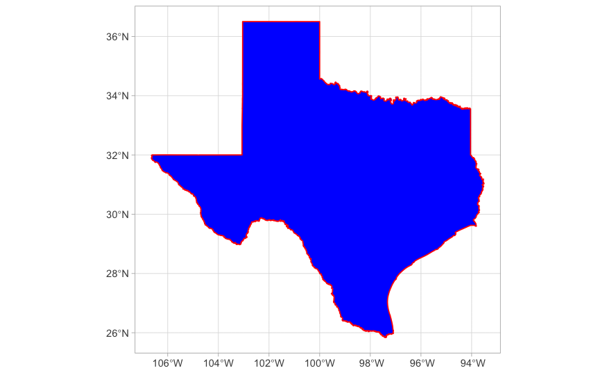

```r
start = "1985-01-01"
end   = "2015-01-01"
state = "TX"

texas = aoi_get(state = state)

# Instantiate plot
ggplot() +
  # Add texas POLYGON
  geom_sf(data = texas, color = "red", fill = "blue") +
  # Apply theme
  theme_light()
```

Next we query NWIS data using the `dataRetrieval` package, specifying: -state -data range -data type -data cd

```r
# Query data
nwis = dataRetrieval::whatNWISdata(
  # State to search
  stateCd = state,
  # Goal date range
  startDt = start, endDt = end,
  # Daily Values
  outputDataTypeCd = "dv",
  # Streamflow
  parameterCd = "00060",
  statCd = '00003')

glimpse(nwis)
```

```
Rows: 650
Columns: 24
$ agency_cd          <chr> "USGS", "USGS", "USGS", "USGS", "USGS", "USGS", "USGS", "USGS", "USGS", "USG…
$ site_no            <chr> "07227420", "07227500", "07227890", "07227920", "07228000", "07233500", "072…
$ station_nm         <chr> "Cramer Ck at US Hwy 54 nr Dalhart, TX", "Canadian Rv nr Amarillo, TX", "Big…
$ site_tp_cd         <chr> "ST", "ST", "ST", "ST", "ST", "ST", "ST", "ST", "ST", "ST", "ST", "ST", "ST"…
$ dec_lat_va         <dbl> 35.75125, 35.47033, 35.72078, 35.66476, 35.93504, 36.20225, 36.23865, 34.848…
$ dec_long_va        <dbl> -102.89317, -101.87963, -101.66253, -101.35100, -100.37069, -101.30599, -100…
$ coord_acy_cd       <chr> "S", "F", "1", "F", "F", "F", "F", "F", "F", "F", "F", "F", "F", "F", "F", "…
$ dec_coord_datum_cd <chr> "NAD83", "NAD83", "NAD83", "NAD83", "NAD83", "NAD83", "NAD83", "NAD83", "NAD…
$ alt_va             <dbl> 3962.24, 2989.16, 2933.19, 2835.84, 2301.50, 2961.63, 2371.29, 3648.20, 2463…
$ alt_acy_va         <dbl> 0.01, 0.10, 0.10, 0.10, 0.10, 0.10, 0.10, 0.10, 0.10, 0.10, 0.10, 0.10, 0.10…
$ alt_datum_cd       <chr> "NGVD29", "NGVD29", "NAVD88", "NGVD29", "NGVD29", "NGVD29", "NGVD29", "NGVD2…
$ huc_cd             <chr> "11090102", "11090105", "11090105", "11090106", "11090106", "11100104", "111…
$ data_type_cd       <chr> "dv", "dv", "dv", "dv", "dv", "dv", "dv", "dv", "dv", "dv", "dv", "dv", "dv"…
$ parm_cd            <chr> "00060", "00060", "00060", "00060", "00060", "00060", "00060", "00060", "000…
$ stat_cd            <chr> "00003", "00003", "00003", "00003", "00003", "00003", "00003", "00003", "000…
$ ts_id              <chr> "131754", "131763", "131775", "131784", "131785", "131789", "295185", "13180…
$ loc_web_ds         <chr> NA, NA, NA, NA, NA, NA, NA, NA, NA, NA, NA, NA, NA, NA, NA, NA, NA, NA, NA, …
$ medium_grp_cd      <chr> "wat", "wat", "wat", "wat", "wat", "wat", "wat", "wat", "wat", "wat", "wat",…
$ parm_grp_cd        <chr> NA, NA, NA, NA, NA, NA, NA, NA, NA, NA, NA, NA, NA, NA, NA, NA, NA, NA, NA, …
$ srs_id             <chr> "1645423", "1645423", "1645423", "1645423", "1645423", "1645423", "1645423",…
$ access_cd          <chr> "0", "0", "0", "0", "0", "0", "0", "0", "0", "0", "0", "0", "0", "0", "0", "…
$ begin_date         <date> 2007-10-01, 1938-04-01, 2010-02-26, 1974-03-01, 1938-04-01, 1945-08-01, 194…
$ end_date           <date> 2020-12-15, 2022-07-17, 2022-07-17, 1989-09-29, 2022-07-17, 2022-07-17, 202…
$ count_nu           <dbl> 4825, 30783, 4521, 5692, 30789, 20911, 22918, 14811, 20013, 8095, 10826, 209…
```

For this we remotely access the gages 2 data set and join it to the above data.

```r
sites = nhdplusTools::get_gagesII(AOI = texas)  %>%
  # Find those that the reference classification is NA and the drainage area is greater then 10
  filter(hcdn_2009 == "", drain_sqkm > 10) %>%
  # Join to the site IDs returned from NWIS
  inner_join(nwis, by = c("staid" = "site_no")) %>%
  # Find those that give a daily mean (stat_cd), and have at least 30 years of data
  filter(count_nu > 30*365) |>
  # Send to a projected transformation
  st_transform(5070)
```

We can see that there are 280 stream flow gauge stations in Texas that fit our criteria.

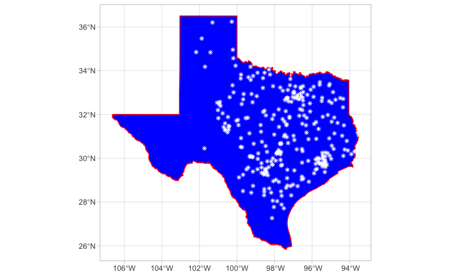

```r
# Instantiate plot
ggplot() +
  # Add texas POLYGON
  geom_sf(data = texas, color = "red", fill = "blue") +
  # Add sites to map
  geom_sf(data = sites, pch = 8, color = "white") +
  # Apply theme
  theme_light()
```

# Dams

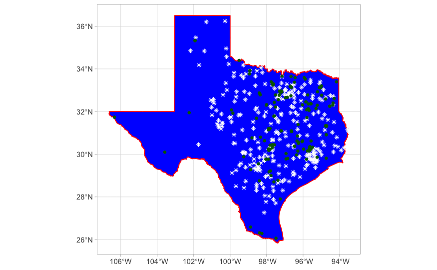

```r
# Read from USACE NID dataset
dams = read.csv('https://nid.usace.army.mil/api/nation/csv', skip = 1) %>%
  # Find those within year range, the state of Texas, and of a given size
  filter(between(Year.Completed, 1995, 2005), State == "Texas") %>%
  # convert table to sf object
  sf::st_as_sf(coords = c('Longitude', 'Latitude'), crs = 4326)  %>%
  # Keep only relevant columns
  select(name = Dam.Name,
         nidid =  NID.ID,
         storage = NID.Storage..Acre.Ft.,
         height =Dam.Height..Ft.,
         completed = Year.Completed) %>%
  # Send to a projected transformation
  st_transform(5070)

# Instantiate plot
ggplot() +
  # Add texas POLYGON
  geom_sf(data = texas, color = "red", fill = "blue") +
  # Add sites to map
  geom_sf(data = sites2, pch = 8, color = "white") +
  # Add dams to map
  geom_sf(data = dams, pch = 16, color = "darkgreen") +
  # Apply theme
  theme_light()
```

As is evident from the plot above, there are many gage locations that don’t have any dams in their vicinity. One way to eliminate these stations is using a spatial query based on a search radius. We can determine an estimation for our search radius based on the upstream drainage area distribution of the streamflow gauges.

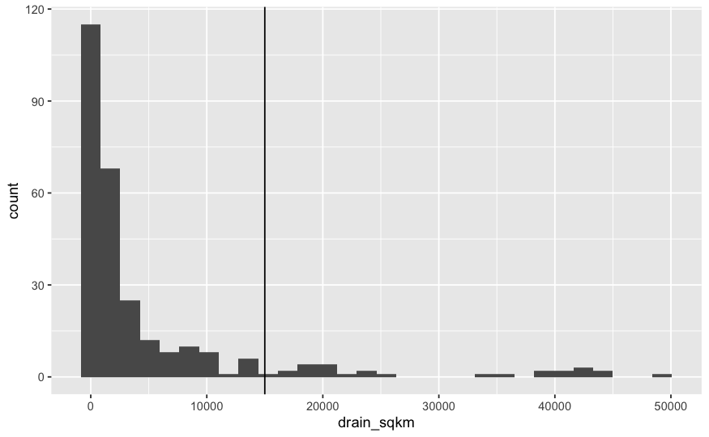

```r
ggplot(data = sites, aes(x = drain_sqkm)) +
  # Generate a histogram
  geom_histogram() +
  geom_vline(xintercept = 15000)
```

```r
lengths(proxy)
```

```
 dams sites
    6    39
```

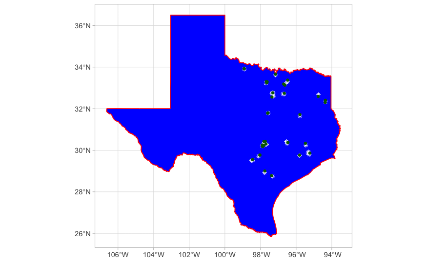

```r
# Instantiate plot
ggplot() +
  # Add texas POLYGON
  geom_sf(data = texas, color = "red", fill = "blue") +
  # Add sites to map
  geom_sf(data = proxy$sites, pch = 8, color = "white") +
  # Add dams to map
  geom_sf(data = proxy$dams, pch = 16, color = "darkgreen") +
  # Apply theme
  theme_light()
```

# Flowlines and Hydrolinking

| staid | comid | nidid | storage | height | name | completed | begin_date | end_date |
| --- | --- | --- | --- | --- | --- | --- | --- | --- |
| 08158920 | 5781345 | TX07223 | 156 | 26.0 | Highway 71 Dam | 1999 | 1978-01-10 | 2022-07-17 |
| 08158920 | 5781345 | TX07494 | 189 | 28.1 | Lantana Regional Detention Dam | 1996 | 1978-01-10 | 2022-07-17 |
| 08177300 | 1638809 | TX07200 | 100 | 22.0 | Larry Lange Dam | 2004 | 1978-06-28 | 2022-07-17 |
| 08178700 | 10839872 | TX07211 | 8741 | 49.0 | Salado Creek WS NRCS Site 15r Dam | 2004 | 1960-09-01 | 2022-07-17 |
| 07312200 | 13730353 | TX07034 | 22 | 29.0 | Brockreide Dam | 1997 | 1960-03-01 | 2022-07-17 |
| 07312200 | 13730353 | TX07042 | 135 | 27.0 | Richardson Estate Dam | 1997 | 1960-03-01 | 2022-07-17 |
| 08057445 | 1260363 | TX09216 | 35 | 12.0 | Cherry Brook Lake Dam | 1995 | 1975-10-01 | 2011-09-30 |
| 08095000 | 5531532 | TX07061 | 410 | 18.6 | City of Clifton Channel Dam | 1998 | 1923-10-01 | 2022-07-17 |
| 08095000 | 5531532 | TX07074 | 731 | 47.0 | Clifton Off Channel Dam | 2000 | 1923-10-01 | 2022-07-17 |

```r
for(i in u){

  years_of_construction = filter(tmp, staid == i)$completed
  y = range(years_of_construction - 15, years_of_construction + 15)

  flows = readNWISdv(site = i, parameterCd  = "00060") |>
    renameNWISColumns() |>
    group_by(year = as.numeric(format(Date, '%Y'))) |>
    summarise(meanQ = mean(Flow, na.rm = TRUE) * 0.028316846592,
              n = n()) |>
    filter(between(year, min(y), max(y)), n > 300) |>
    right_join(data.frame(year = min(y):max(y)), by = "year")

  p[[length(p)  + 1]] = ggplot(data = flows) +
    geom_line(aes(x = year, y = meanQ )) +
    geom_vline(xintercept = years_of_construction, color  = "red") +
    labs(title = i, x = "Year", y = "Flow (cfs)")
}
```

[output not shown]

```r
tmp = findNLDI(nwis = joined$STAID[1],
               nav = "UT",
               find= c('flowlines', "basin"))

ggplot() +
  geom_sf(data = tmp$basin) +
  geom_sf(data = tmp$UT_flowlines) +
  geom_sf(data = joined, pch = 8, color = "red", cex = 5) +
  geom_sf(data = filter(dams2, NID.ID %in% joined$NID.ID), pch = 16, color = "darkgreen", cex = 5)
```

[output not shown]

```r
flows = readNWISdv(siteNumbers = joined$STAID, parameterCd = "00060")  %>%
  renameNWISColumns() %>%
  mutate(Y = as.numeric(format(Date, "%Y")))  %>%
  group_by(Y)  %>%
  summarize(meanQ  = mean(Flow))


ggplot(data = flows, aes(x = Y, y = meanQ )) +
  geom_line(color = "blue") +
  geom_vline(xintercept =  2004, lty = 2, color = 'red', lwd = 1.5) +
  theme_minimal()
```

[output not shown]

```r
r = rast("/vsicurl/https://storage.googleapis.com/feddata-r/nlcd/2019_Land_Cover_L48.tif")

vAOI = project(vect(tmp$basin), crs(r))

lc = crop(r, vAOI, snap = "out") %>%
  mask(vAOI)


freq(lc) %>%
  arrange(-count)  %>%
  mutate(sqkm = count * prod(res(lc)) /1e6)
```

[output not shown]